# text2vec in R

vicshi94

2024-02-26

# text2vec in R

*text2vec* version == 0.6.4. Some codes might slightly different with other documents

More details：

https://cran.r-project.org/web/packages/text2vec/vignettes/text-vectorization.html

```r
# suppressMessages() for not displaying some information
suppressMessages(library(text2vec))
```

## 1. Words Similarity（TCM+GloVe）

Data Source：https://github.com/m-clark/text-analysis-with-R/blob/master/data/text8.zip

```r
wiki = readLines("text8", n = 1, warn = FALSE)
```

### 1.1 Create a iterator

The iterator function allows us to hide most of details about input and to process data in memory-friendly chunks.

```r
it = itoken(
  wiki, #corpus
  preprocessor = tolower, # lowercase
  tokenizer = space_tokenizer, #* Note1
  # n_chunks = 10, # number of chunks
  # ids = , # vector of document ids. If not provided,ids will be assigned.
  progressbar = FALSE # whether to show progress bar
)
```

*Note 1: In most cases, we use *word_tokenizer* as tokenizer, here we use *space_tokenizer* for speed up the processing. The *space_tokenizer* will split the corpus by space, so it is faster but worse than *word_tokenizer*.

```r
test_sentence <- "word1 word2. word3?"
word_tokenizer_res <- word_tokenizer(test_sentence)[[1]]
space_tokenizer_res <- space_tokenizer(test_sentence)[[1]]
print(paste("raw sentence：",test_sentence))
print(paste("word_tokenizer：", paste(word_tokenizer_res,collapse = " ")))
print(paste("space_tokenizer：", paste(space_tokenizer_res,collapse = " ")))
```

```
## [1] "raw sentence： word1 word2. word3?"
## [1] "word_tokenizer： word1 word2 word3"
## [1] "space_tokenizer： word1 word2. word3?"
```

### 1.2 Create vocabulary

```r
vocab = create_vocabulary(it)
```

Moreover, we can generate vocabulary using n-grams instead of words.

```r
vocab_2grams = create_vocabulary(
  it, ngram = c(1L, 2L) # ngram_min = 1, ngram_max = 2
)

print(paste("Length of vocabulary (word): ", dim(vocab)[1]))
print(paste("Length of vocabulary (2-grams): ", dim(vocab_2grams)[1]))
```

```
## [1] "Length of vocabulary (word):  253854"
## [1] "Length of vocabulary (2-grams):  4400703"
```

The significant increase in vocabulary length! This not only leads to longer training time for subsequent models but also affects the model’s accuracy. Therefore, we need to perform pruning on the vocabulary (using the original vocabulary as an example).

### 1.3 Prune Vocabulary

First, we can use stopwords:

```r
stop_words = c("i", "me", "my", "myself", "we", "our", "ours", "ourselves", "you", "your", "yours")
vocab = create_vocabulary(
  it,
  stopwords = stop_words
  )
```

Alternatively, we can use the prune_vocabulary() function in text2vec:

```r
pruned_vocab = prune_vocabulary(
  vocab,
  term_count_min = 10, # minimum number of occurences over all documents
  # doc_proportion_max = 0.5, # maximum proportion of documents which should contain term
  )
# other args:
# term_count_max, doc_proportion_min, doc_count_min, doc_count_max,
# vocab_term_max -> maximum number of terms in vocabulary

print(paste("Length of vocabulary (raw): ", dim(vocab)[1]))
print(paste("Length of vocabulary (pruned):：", dim(pruned_vocab)[1]))

# Create a structure for various following tasks (e.g., matrix decomposition)
vectorizer = vocab_vectorizer(vocab)
```

[output not shown]

### 1.4 Projection 1: Term-co-occurrence Matrix (TCM)

Often used with GloVe

Example：

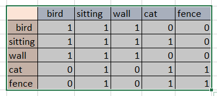

```r
tcm = create_tcm(
  it, vectorizer,
  skip_grams_window = 5L, # co-occurrence window size
  # skip_grams_window_context = "symmetric" OR "right" OR "left"
  )
```

### 1.5 GloVe

```r
# define GloVe model
glove = GlobalVectors$new(
  rank = 50, # desired dimension for word vectors
  # the 50 here is just a example for presentation, please refer to the papers in real task
  x_max = 10, # maximum number of co-occurrences to use in the weighting function
  )
# see the GloVe paper for details: http://nlp.stanford.edu/pubs/glove.pdf

wv_main = glove$fit_transform(
  tcm,
  n_iter = 25, # number of iteration
  convergence_tol = 0.001,
  # n_threads = 8
  ) # the settings here is just a example**

# word vectors
wv_context = glove$components
word_vectors = wv_main + t(wv_context)
```

**Note 2: There are many parameters involved in the *glove$fit_transform()* function that require machine learning knowledge, which will not be elaborated here. Some relevant terms include but are not limited to stochastic gradient descent (SGD), iterative, convergence, and learning rate.

PS: During the research process, I came across a suggestion not to set the learning rate because the AdaGrad algorithm is used, but I haven’t further verified this information.

### 1.6 Application: Word similarity

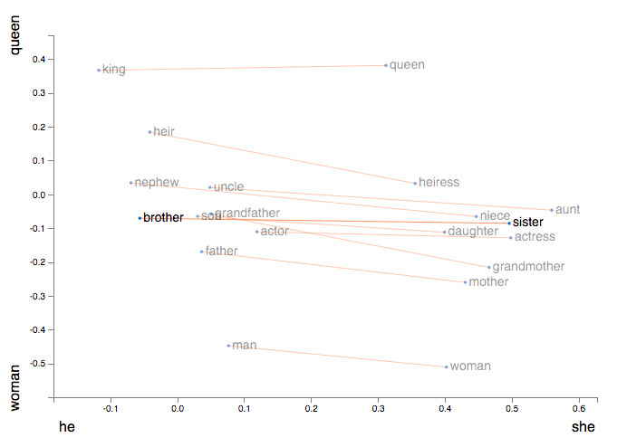

Next, we will examine the relationships between two sets of word vectors:

paris - france + germany = ?

son - {man words} + {woman words} = ?

```r
test1 = word_vectors["paris", , drop = FALSE] -
  word_vectors["france", , drop = FALSE] +
  word_vectors["germany", , drop = FALSE]
# cosine similarity
test1_cos_sim = sim2(
  x = word_vectors, y = test1,
  method = "cosine",
  norm = "l2")
# l2-norm refers to the sum of squares of each element in a vector, followed by taking the square root
# Our model is relatively rudimentary, so let's relax and see if the word "berlin" appears in the top five words.
head(sort(test1_cos_sim[,1], decreasing = TRUE), 5)
```

```
##     paris    munich    berlin   germany   leipzig
## 0.8076480 0.7724002 0.7351536 0.6840144 0.6578420
```

```r
test2 = word_vectors["son", , drop = FALSE] -
  word_vectors["man", , drop = FALSE] +
  word_vectors["woman", , drop = FALSE] -
  word_vectors["men", , drop = FALSE] +
  word_vectors["women", , drop = FALSE] #**

test2_cos_sim = sim2(x = word_vectors, y = test2, method = "cosine", norm = "l2")
head(sort(test2_cos_sim[,1], decreasing = TRUE), 5)
```

```
##  daughter       son      wife    eldest   husband
## 0.8064695 0.7728796 0.7664093 0.7523712 0.7088653
```

** Note3: A specific dimension can be strengthen by adding more relationship pairs (see Garg et al., 2018).

Garg, N., Schiebinger, L., Jurafsky, D., & Zou, J. (2018). Word embeddings quantify 100 years of gender and ethnic stereotypes. *Proceedings of the National Academy of Sciences*, *115*(16). https://doi.org/10.1073/pnas.1720347115

## 2. Downstream tasks: Supervised Learning

In the previous section, we mainly focused on the word embedding part. However, when transforming text into data, it is often just the beginning. It can further serve numerous downstream tasks, such as topic modeling and supervised learning tasks. In the next section, we will continue to introduce text2vec using **Sentiment Analysis** (supervised learning) as an example.

### 2.1 Sampling

```r
suppressMessages(library(data.table))

# movie_review is from text2vec package
data("movie_review")
setDT(movie_review) # transform data into data.table
setkey(movie_review, id) # set the unique key

# head(movie_review)
```

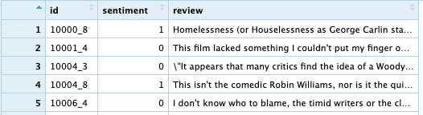

Split into training set and test set:

```r
set.seed(20240223)
train_idx <- sample(nrow(movie_review), 0.8 * nrow(movie_review)) # generate by index
train_set <- movie_review[train_idx] # make training set
test_set <- movie_review[-train_idx] # make test set
# print(head(train_set))
```

```r
it_train = itoken(
  train_set$review, # corpora
  preprocessor = tolower,
  tokenizer = word_tokenizer,
  ids = train_set$id,
  progressbar = FALSE
  )
vocab_train = create_vocabulary(it_train, ngram = c(1L, 2L))

# test_sample should follow the same settings
it_test = itoken(
  test_set$review, # 语料
  preprocessor = tolower,
  tokenizer = word_tokenizer,
  ids = test_set$id,
  progressbar = FALSE
  )

vocab_test = create_vocabulary(it_test, ngram = c(1L, 2L))

bigram_vectorizer = vocab_vectorizer(vocab_train)
```

### 2.2 Projection 2: DTM

In the previous section, we focused on TCM. In this section, we will introduce another projection method, document-term matrix (DTM).

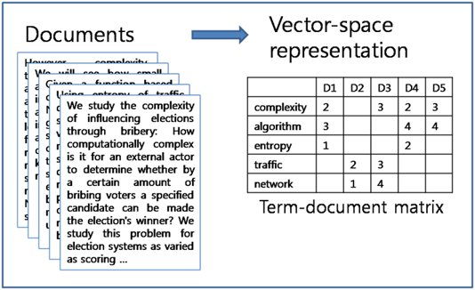

```r
# generate a dtm based on vocabulary
dtm_train = create_dtm(
  it_train,
  bigram_vectorizer
  )
print(dim(as.matrix(dtm_train))) # check the dimension of dtm
```

```
## [1]   4000 404944
```

```r
## 4000 docs x n n-grams

dtm_test = create_dtm(it_test, bigram_vectorizer)
```

**Feature hashing**

We can also use feature hashing to create DTM:

> If you are not familiar with feature hashing (the so-called “hashing trick”) I recommend you start with the [Wikipedia article](https://en.wikipedia.org/wiki/Feature_hashing), then read the [original paper](http://alex.smola.org/papers/2009/Weinbergeretal09.pdf) by a Yahoo! research team. This technique is very fast because we don’t have to perform a lookup over an associative array. Another benefit is that it leads to a very low memory footprint, since we can map an arbitrary number of features into much more compact space. This method was popularized by Yahoo! and is widely used in [Vowpal Wabbit](https://github.com/VowpalWabbit/vowpal_wabbit).

According to the documents and my tests, this method would much faster. However, perform worse.

```r
h_vectorizer = hash_vectorizer(hash_size = 2 ^ 14, ngram = c(1L, 2L))

dtm_train = create_dtm(it_train, h_vectorizer)
```

### 2.3 Transform DTM

1. Normalization

> By “normalization” we assume *transformation* of the *rows* of DTM so we adjust values measured on different scales to a notionally common scale. For the case when length of the documents vary we can apply “L1” normalization. It means we will transform rows in a way that sum of the row values will be equal to 1:

```r
dtm_train_l1_norm = normalize(dtm_train, "l1")
```

2. TF-IDF

Hence, we can increase or decrease weights of terms/ngrams by using TF-IDF transformation

```r
tfidf = TfIdf$new() # create tf-idf model
dtm_train_tfidf = fit_transform(dtm_train, tfidf) # training set
dtm_test_tfidf = transform(dtm_test, tfidf) # test set
```

### 2.4 Fitting

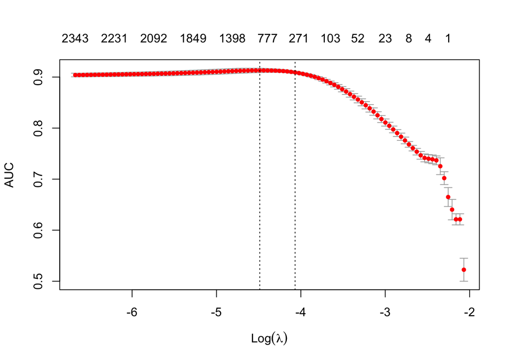

```r
suppressMessages(library(glmnet))

NFOLDS = 4 # cross-validation, default as 10

# sentiment classifier
senti_classifier = cv.glmnet(
  x = dtm_train_tfidf, # input
  y = train_set$sentiment, # label
  family = "binomial", # logit regression
  alpha = 1, # 1 for lasso, 0 for ridge
  type.measure = "auc", # performance matric
  nfolds = NFOLDS,
  keep = TRUE, # whether to keep the nfold results
  thresh = 1e-3,
  maxit = 1e3
  )
plot(senti_classifier)
```

The larger the value of λ, the stronger the regularization effect, and the smaller the coefficients. The closer the AUC value from cross-validation is to 1, the better the model performance.

```r
# check the results in cv.glmnet
# print(names(res))
# more details about cv.glmnet: https://glmnet.stanford.edu/articles/glmnet.html

print(paste("max AUC =", round(max(senti_classifier$cvm), 4)))
```

```
## [1] "max AUC = 0.913"
```

```r
# estimate of standard error of cvm
# print(paste("sd.max_AUC =", round(res$cvsd[which.max(senti_classifier$cvm)], 4)))
# the values of lambda used in the fits
# print(paste("lambda.max_AUC =", round(res$lambda[which.max(senti_classifier$cvm)], 4)))
```

let’s validate the performance of the model on the test set.

```r
preds = predict(senti_classifier, newx = dtm_test_tfidf, type = "response")[,1]
glmnet:::auc(test_set$sentiment, preds) # AUC
```

```
## [1] 0.9073449
```